# INFO 2301 Tutorial - Week 4 - PHP Basics Cont'd

## Forms

### Single File Forms

In the previous section, we learned how to create a form and process it. That method involved using two files; one for the form and another for the processing. This section will show you how to create a single file form. Almost everything is the same except for two things:

- The form and processing are in one file, a `php` file. This is important as our file will include processing blocks as well.
- An `IF () {} ELSE {}` block to determine if the form has been submitted.

A simple implmentation is as follows:

```php
<?php
// The following checks if the submit button was pressed
if (isset($_POST['submit'])){
    $name = htmlspecialchars($_POST['name']);
    $age = (int)$_POST['age'];

  echo "Hi $name.<br>";
    echo "You are $age years old.";
}
// If it wasn't pressed, then show the form
else {
?>
<!doctype html>
<html lang="en">
<head>
    <meta charset="UTF-8">
    <title>Document</title>
</head>
<body>
    <!-- Pay attention to the action attrib. -->
    <form action="<?php echo $_SERVER['PHP_SELF']; ?>" method="post">
    <p>Your name: <input type="text" name="name" /></p>
    <p>Your age: <input type="text" name="age" /></p>
        <!-- The name attrib. for the submit button is important
        for this method since we need to detect whether it has been
        pressed-->
    <p><input type="submit" name="submit"/></p>
</form>
</body>
</html>
<?php
}
?>
```

### Checkboxes with Arrays

Understanding this section requires some knowledge of arrays and loops. Unfortunately, arrays are handled in the next section; please come back once you have grasped the basics of arrays to see their implementation in form checkboxes. The following code sample demonstrates their use:

```php
<?php
if (isset($_GET['submit'])) {
  $theHobbies = $_GET['hobbies'];
  $theName = $_GET['name'];

  echo "Assalamu'alaikum $theName <br>";

  if (empty($theHobbies)) {
    echo "You didn't select any hobbies.";
  }
  else {
    $noHobby = count($theHobbies);
    if ($noHobby>1) {
      echo "You have $noHobby hobbies.";
      echo "Your hobbies are ";
      for ($i = 0; $i < $noHobby-1; $i++) {
        echo "$theHobbies[$i], ";
      }
      echo "and ". $theHobbies[$noHobby-1] . ".";
    }
    else {
      echo " You have exactly $noHobby hobby.";
      echo " Your hobby is $theHobbies[0].";
    }
  }
}
else {
?>
<!doctype html>
<html lang="en">
<head>
  <meta charset="UTF-8">
  <title>Document</title>
</head>
<body>
  <form method="get" action="<?php echo $_SERVER['PHP_SELF']?>">
    <p>Name: <input type="text" name="name"></p>
    <p>
      Gaming      <input type="checkbox" name="hobbies[]" value="gaming"><br>
      Knitting    <input type="checkbox" name="hobbies[]" value="knitting"><br>
      Programming <input type="checkbox" name="hobbies[]" value="programming"><br>
      Makan       <input type="checkbox" name="hobbies[]" value="makan"><br>
    </p>
    <p><input type="submit" name="submit" value="Submit"></p>
  </form>
</body>
</html>
<?php
}
?>
```

## Arrays

Arrays are an importan part of PHP and are used in several places including for functions relating to database operations. The following code demonstrates a couple of array-related functions:

```php
<?php
$names = array ("Khalid", "Sajid", "Hussain");
$random_things = array ("string", true, 50, 'k');

// <pre> tags help code readability
echo "<pre>";
print_r ($names);
// The following prints a more detailed view of the array
// var_dump ($names);
echo "</pre>";

echo $names[2] . "<br>";
echo $random_things[2] . "<br>";
?>
```

Other array functions and their usage can be viewed at the [PHP.net Arrays](http://php.net/manual/en/function.array.php) page.

### Associative Arrays

Arrays can also have a string or a mix of strings and integer indices instead of indices consisting of integers only as shown in the last section. The following snippet demonstrates this:

```php
<?php
$organic_food = array ("a" => "apple", "b" => "banana", 45 => "carrot");
echo $organic_food["a"] . "<br>";
echo $organic_food["b"] . "<br>";
echo $organic_food[45] . "<br>";

echo "<pre>";
print_r ($organic_food);
// The following gives a more detailed view of the array
// var_dump ($organic_food);
echo "</pre>";
?>
```

### Multi-Dimensional Arrays

It is also possible to create multi-dimensional arrays, for example 2 by 2 or 3 x 2 arrays. An example to demonstrate this is shown:

```php
<?php
$organic_food = array (
    "fruits"     => array("apple", "pear", "watermelon"),
    "vegetables" => array("carrot", "cucumber", "lettuce")
);
// Output: watermelon
echo $organic_food["fruits"][2] . "<br>";

// Output: carrot
echo $organic_food["vegetables"][0] . "<br>";
?>
```

**Note**: You can also use associate arrays inside a multi-dimensional array. This is shown below [^1]:

```php
<?php
$fruits = array (
    "fruits"  => array("a" => "orange", "b" => "banana", "c" => "apple"),
    "numbers" => array(1, 2, 3, 4, 5, 6),
    "holes"   => array("first", 5 => "second", "third")
);
?>
```

# MySQL

MySQL is a relational-database management system which has grown popular in use with PHP. This section will show you how to get started using it. Before doing anything else, ensure that you start your MySQL server on your computer.

Start a MySQL console session to try out some commands. If using XAMPP, click on the `Shell` button from the XAMPP Control Panel.

[figure not shown]

This was start a console which can access all your XAMPP executables, MySQL being one of them. To start using MySQL from the console, type:

```bash
mysql -u root
```

The above command assumes that you have not set a password and that your username is `root`. If your username is different and you *have* set a password, then use the following command while switching the default values with your relevant values:

```bash
mysql -u [your username] -p [your password]
```

You shall then be presented with a command window as follows:

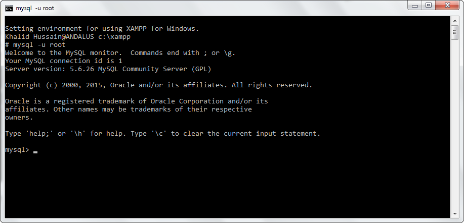

This window is where you can type MySQL commands and queries to obtain results from databases or to perform other operations related to your MySQL installation. This can also be achieved from using your PhpMyAdmin which comes with XAMPP or other similar web software.

Try out some of the following commands:

```
show databases;
use phpmyadmin;
show tables;
```

[^1]: (http://php.net/manual/en/function.array.php#example-5561)